# 06-class-ds4ir-assignment

seu nome aqui

27-07-2020

# Assignment

1. Valendo-se do World Values Survey, responda: qual é o percentual de pessoas que confia em partidos políticos na Argentina? Você diria que o número é estatisticamente diferente do que observamos Brasil?

O code chunk abaixo já traz o código para carregar a base de dados, e o livro de códigos está disponível na pasta `data`.

```r
wvs <- readRDS(here("./data/EVS_WVS_Cross-National_Wave_7_joint_core_R_v1_1.rds"))

partidos_arg <- wvs %>%
  select(C_COW_ALPHA, A_YEAR, Q72) %>%
  filter(C_COW_ALPHA == "ARG") %>%
  mutate(confia_em_partidos = case_when(Q72 %in% c(1, 2) ~ 1,
                                        TRUE ~ 0)) %>%
  summarise(soma_confiam = sum(confia_em_partidos),
            total_entrevistados = n(),
            prop = round(soma_confiam/total_entrevistados * 100, 2))

prop.test(partidos_arg$soma_confiam, partidos_arg$total_entrevistados, .5)
```

```
##
##  1-sample proportions test with continuity correction
##
## data:  partidos_arg$soma_confiam out of partidos_arg$total_entrevistados, null probability 0.5
## X-squared = 566.82, df = 1, p-value < 2.2e-16
## alternative hypothesis: true p is not equal to 0.5
## 95 percent confidence interval:
##  0.1042213 0.1459789
## sample estimates:
##         p
## 0.1236291
```

2. identifique o país com maior nível de desconfiança na Imprensa, e construa o intervalo de 95% em torno da média.

```r
imprensa <- wvs %>%
  select(C_COW_ALPHA, A_YEAR, Q66) %>%
  mutate(n_confia_na_imp = case_when(Q66 %in% c(1, 2) ~ 0,
                                        TRUE ~ 1)) %>%
  group_by(C_COW_ALPHA) %>%
  summarise(soma_n_confiam = sum(n_confia_na_imp),
            total_entrevistados = n(),
            prop = round(soma_n_confiam/total_entrevistados * 100, 2)) %>%
  arrange(desc(prop)) %>%
  slice(1)

est_imprensa <- prop.test(imprensa$soma_n_confiam, imprensa$total_entrevistados, .5)
```

3. Escreva uma frase interpretando as estimativas encontradas na pergunta 2. Os valores da média e do intervalo de confiança devem ser reportados de maneira dinâmica, por meio de objetos que você criou na pergunta anterior.

O Egito é o país com maior nível de desconfiança na imprensa. Em sua amostra, 91.6% dos entrevistados afirmam não confiar nessa instituição. Se repetíssemos essa pesquisa infinitas vezes, 95% das médias estariam entre 89.8% e 93.1% da população.

4. Nos modelos que rodamos durante a aula para compreender a ascensão do Partido Nazista, utilizamos o número absoluto de votos em cada distrito como variável dependente. Porém, pode-se fazer o argumento de que o mais importante é a proporção dos votos que o Partido Nazista ganhou dentro de cada distrito, e não o número total.

Utilize o banco de dados para testar essa hipótese, fazendo as transformações necessárias. Os resultados são diferentes?

```r
nazis <- read_csv(here("./data/nazis.csv")) %>%
  mutate(nazi_prop = nazivote/nvoter)

m <- lm(nazi_prop ~ shareunemployed + sharewhite + shareblue + shareself, data = nazis) # rodando o modelo

summ(m, confint = TRUE) # tabela de resultados
```

| Observations | 681 |
| --- | --- |
| Dependent variable | nazi_prop |
| Type | OLS linear regression |

| F(4,676) | 20.03 |
| --- | --- |
| R² | 0.11 |
| Adj. R² | 0.10 |

|  | Est. | 2.5% | 97.5% | t val. | p |
| --- | --- | --- | --- | --- | --- |
| (Intercept) | 0.05 | -0.13 | 0.23 | 0.57 | 0.57 |
| shareunemployed | -0.08 | -0.28 | 0.12 | -0.79 | 0.43 |
| sharewhite | 0.23 | 0.05 | 0.41 | 2.56 | 0.01 |
| shareblue | 0.49 | 0.30 | 0.68 | 5.08 | 0.00 |
| shareself | 1.06 | 0.56 | 1.56 | 4.16 | 0.00 |

Standard errors: OLS

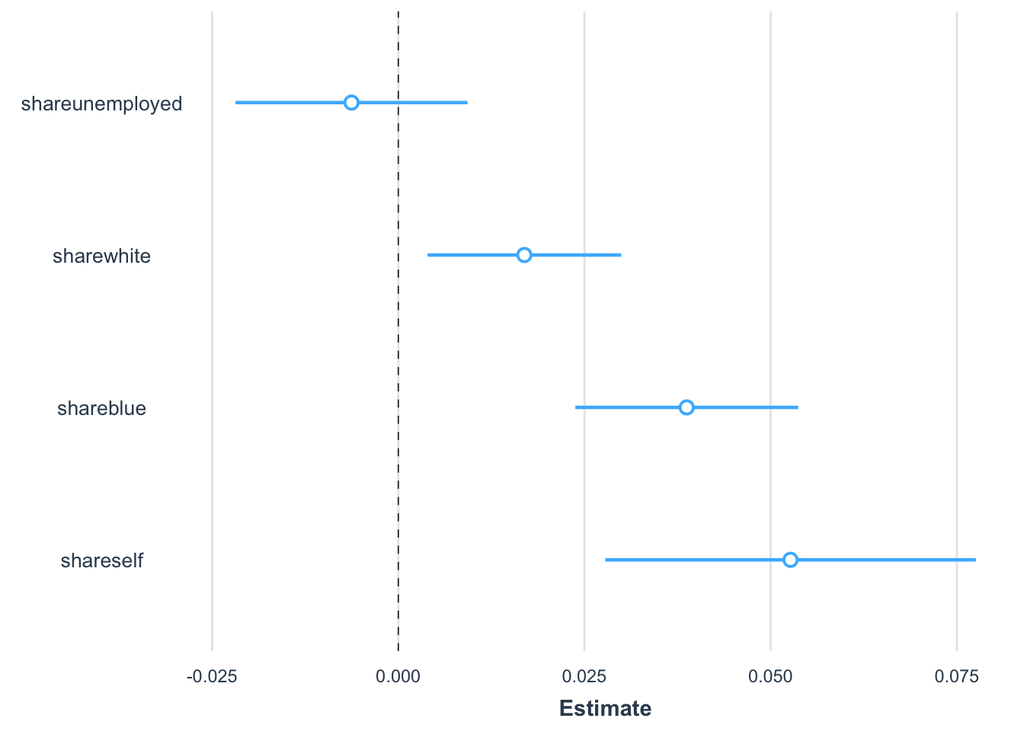

```r
plot_summs(m, scale = TRUE) # gráfico com resultados
```

5. Produza um documento .html com o resultado de sua análise

**Observação**: Não se esqueça de colocar seu nome.